# data science hw01 for mpg data

# Homework 2

## read data and confirm data type , we can see that ‘horsepower’ althought is numerice but type is character , data have 398 observes and 8 variables(mpg is our label so have 7 features)

```r
library('tidyverse')
```

```r
library('ggplot2')
library(boot)
feature_name_mpg = c('mpg','cylinders','displacement','horsepower','weight','acceleration','model year','origin','car name')
data_mpg = read.table("C:\\Users\\xx958\\OneDrive\\桌面\\nycu 碩一_上\\數據科學\\mpg\\auto-mpg.data",head=F,col.names=feature_name_mpg)
data_mpg = data_mpg[1:8]

str(data_mpg)
```

```
## 'data.frame':    398 obs. of  8 variables:
##  $ mpg         : num  18 15 18 16 17 15 14 14 14 15 ...
##  $ cylinders   : int  8 8 8 8 8 8 8 8 8 8 ...
##  $ displacement: num  307 350 318 304 302 429 454 440 455 390 ...
##  $ horsepower  : chr  "130.0" "165.0" "150.0" "150.0" ...
##  $ weight      : num  3504 3693 3436 3433 3449 ...
##  $ acceleration: num  12 11.5 11 12 10.5 10 9 8.5 10 8.5 ...
##  $ model.year  : int  70 70 70 70 70 70 70 70 70 70 ...
##  $ origin      : int  1 1 1 1 1 1 1 1 1 1 ...
```

## change type of data to numerice but probuct NA

```r
for (i in names(data_mpg)){
  data_mpg[[i]]=as.numeric(data_mpg[[i]])
}
```

## find NA , and horsepower have 6 NA Missing value

```r
colSums(is.na(data_mpg))
```

```
##          mpg    cylinders displacement   horsepower       weight acceleration
##            0            0            0            6            0            0
##   model.year       origin
##            0            0
```

```r
data_mpg[is.na(data_mpg$horsepower),]
```

```
##      mpg cylinders displacement horsepower weight acceleration model.year
## 33  25.0         4           98         NA   2046         19.0         71
## 127 21.0         6          200         NA   2875         17.0         74
## 331 40.9         4           85         NA   1835         17.3         80
## 337 23.6         4          140         NA   2905         14.3         80
## 355 34.5         4          100         NA   2320         15.8         81
## 375 23.0         4          151         NA   3035         20.5         82
##     origin
## 33       1
## 127      1
## 331      2
## 337      1
## 355      2
## 375      1
```

## and remove missing value

```r
miss_value = which(is.na(data_mpg$horsepower)==1)
data_mpg_remove_miss = data_mpg[-miss_value,]
```

## confirm data

```r
str(data_mpg_remove_miss)
```

```
## 'data.frame':    392 obs. of  8 variables:
##  $ mpg         : num  18 15 18 16 17 15 14 14 14 15 ...
##  $ cylinders   : num  8 8 8 8 8 8 8 8 8 8 ...
##  $ displacement: num  307 350 318 304 302 429 454 440 455 390 ...
##  $ horsepower  : num  130 165 150 150 140 198 220 215 225 190 ...
##  $ weight      : num  3504 3693 3436 3433 3449 ...
##  $ acceleration: num  12 11.5 11 12 10.5 10 9 8.5 10 8.5 ...
##  $ model.year  : num  70 70 70 70 70 70 70 70 70 70 ...
##  $ origin      : num  1 1 1 1 1 1 1 1 1 1 ...
```

## drawing matrix of scatter plot and find displacement ,horsepower and weight have patten with mpg

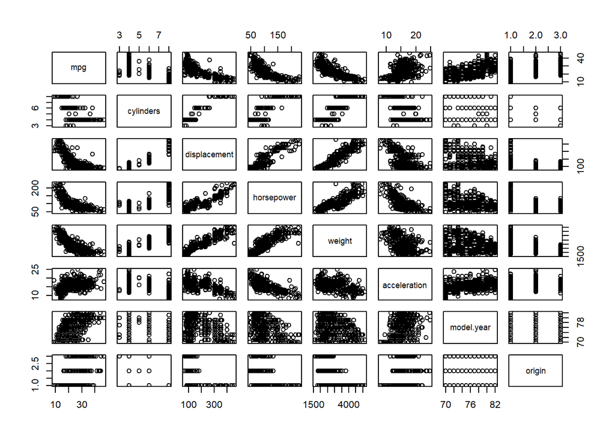

```r
pairs(mpg~., data_mpg_remove_miss)
```

## cylinders and origin is discrete data so drawing box-plots with mpg , and find medians are opposite

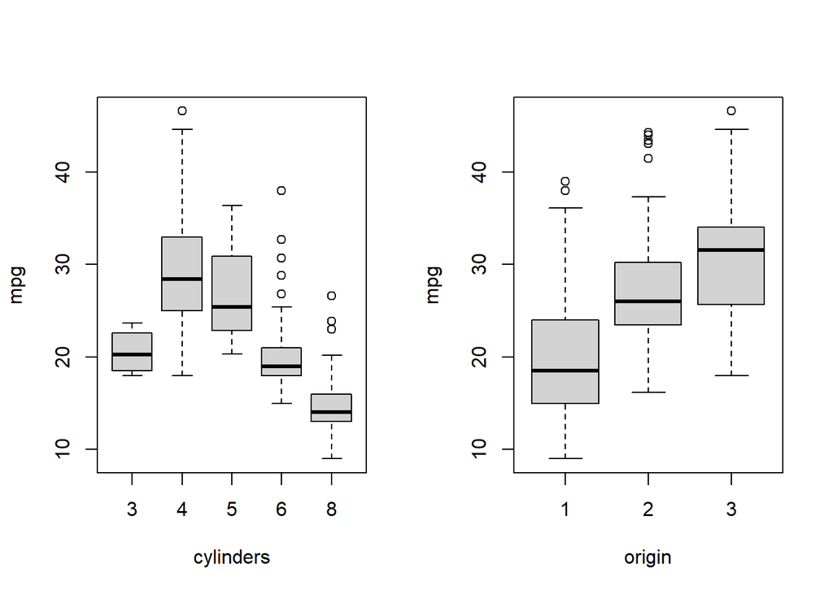

```r
par(mfrow=c(1,2))
boxplot(mpg  ~ cylinders, data = data_mpg_remove_miss)
boxplot(mpg  ~ origin , data = data_mpg_remove_miss)
```

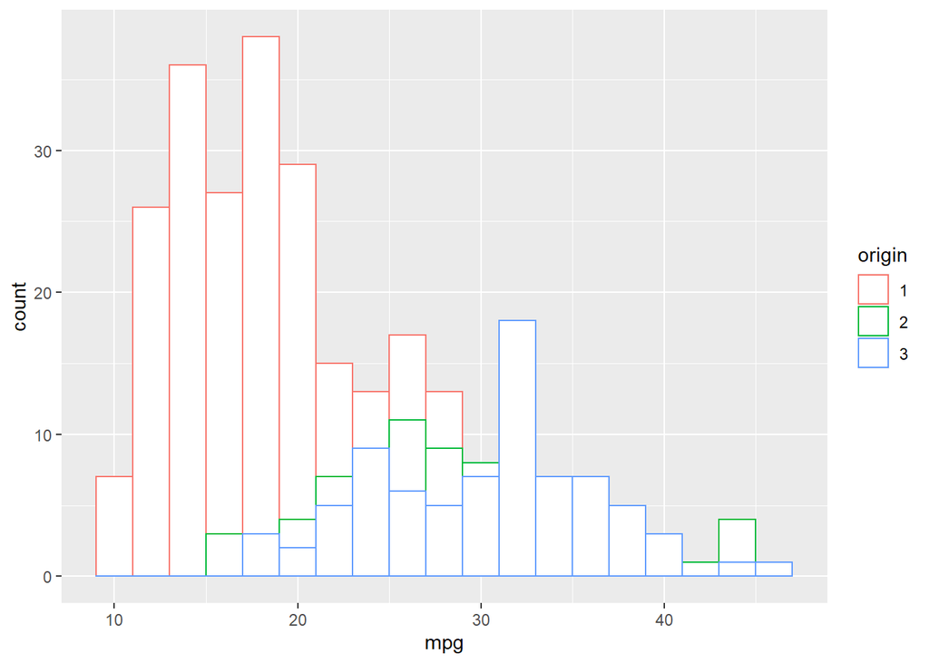

```r
data_mpg_remove_miss[['origin']]=as.character(data_mpg_remove_miss[['origin']])
ggplot(data_mpg_remove_miss,aes(x=mpg,group=origin,color=origin))+
  geom_histogram(binwidth=2,fill="white",position="identity")
```

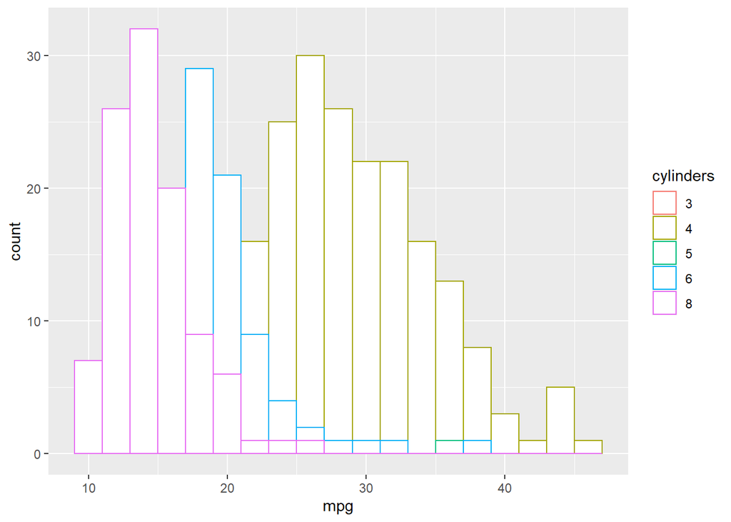

```r
data_mpg_remove_miss[['cylinders']]=as.character(data_mpg_remove_miss[['cylinders']])
ggplot(data_mpg_remove_miss,aes(x=mpg,group=cylinders,color=cylinders))+
  geom_histogram(binwidth=2,fill="white",position="identity")
```

# Homework 3

by homework 2

# first method

we can use average of horsepower to instead missing value on horsepower

and feature horsepower mean is 104.4694 ,Confidence interval is (100.6472,108.2916) for mean at $\alpha$ =0.05

```r
t.test(data_mpg_remove_miss$horsepower,conf.level = 0.95)
```

```
##
##  One Sample t-test
##
## data:  data_mpg_remove_miss$horsepower
## t = 53.737, df = 391, p-value < 2.2e-16
## alternative hypothesis: true mean is not equal to 0
## 95 percent confidence interval:
##  100.6472 108.2916
## sample estimates:
## mean of x
##  104.4694
```

```r
data_mpg_mean = data_mpg
data_mpg_mean[miss_value,]$horsepower=mean(data_mpg_remove_miss$horsepower)
colSums(is.na(data_mpg_mean))
```

```
##          mpg    cylinders displacement   horsepower       weight acceleration
##            0            0            0            0            0            0
##   model.year       origin
##            0            0
```

```r
data_mpg_mean[miss_value,]
```

```
##      mpg cylinders displacement horsepower weight acceleration model.year
## 33  25.0         4           98   104.4694   2046         19.0         71
## 127 21.0         6          200   104.4694   2875         17.0         74
## 331 40.9         4           85   104.4694   1835         17.3         80
## 337 23.6         4          140   104.4694   2905         14.3         80
## 355 34.5         4          100   104.4694   2320         15.8         81
## 375 23.0         4          151   104.4694   3035         20.5         82
##     origin
## 33       1
## 127      1
## 331      2
## 337      1
## 355      2
## 375      1
```

# second method

we also can use median of horsepower to instead missing value on horsepower

```r
bootMedian <- function(data, indices) median(data[indices])
median_of_horsepower <- boot(data_mpg_remove_miss$horsepower, bootMedian, R = 1000)

mean(median_of_horsepower$t)
```

```
## [1] 93.2055
```

```r
sd(median_of_horsepower$t)
```

```
## [1] 2.136372
```

```r
data_mpg_median = data_mpg
data_mpg_median[miss_value,]$horsepower=mean(median_of_horsepower$t)
colSums(is.na(data_mpg_median))
```

```
##          mpg    cylinders displacement   horsepower       weight acceleration
##            0            0            0            0            0            0
##   model.year       origin
##            0            0
```

```r
data_mpg_median[miss_value,]
```

```
##      mpg cylinders displacement horsepower weight acceleration model.year
## 33  25.0         4           98    93.2055   2046         19.0         71
## 127 21.0         6          200    93.2055   2875         17.0         74
## 331 40.9         4           85    93.2055   1835         17.3         80
## 337 23.6         4          140    93.2055   2905         14.3         80
## 355 34.5         4          100    93.2055   2320         15.8         81
## 375 23.0         4          151    93.2055   3035         20.5         82
##     origin
## 33       1
## 127      1
## 331      2
## 337      1
## 355      2
## 375      1
```

# third method

on plot we can see that horsepower have high Multicollinearity with displacement and weight , so I try fit a linear regression to predict NA , can see that p-value of displacement and weight is smaller than $\alpha$ =0.05 , so horsepower have linear association with displacement and weight

```r
horsepower_regression = lm(horsepower~displacement+weight ,data=data_mpg_remove_miss)
horsepower_predict = predict(horsepower_regression,data_mpg[miss_value,][,c(3,5)])
summary(horsepower_regression)
```

```
##
## Call:
## lm(formula = horsepower ~ displacement + weight, data = data_mpg_remove_miss)
##
## Residuals:
##     Min      1Q  Median      3Q     Max
## -51.136 -10.421  -0.779   8.650  60.251
##
## Coefficients:
##               Estimate Std. Error t value Pr(>|t|)
## (Intercept)  25.874948   4.546534   5.691 2.49e-08 ***
## displacement  0.257433   0.022536  11.423  < 2e-16 ***
## weight        0.009587   0.002776   3.453 0.000615 ***
## ---
## Signif. codes:  0 '***' 0.001 '**' 0.01 '*' 0.05 '.' 0.1 ' ' 1
##
## Residual standard error: 16.78 on 389 degrees of freedom
## Multiple R-squared:  0.8109, Adjusted R-squared:  0.8099
## F-statistic: 833.9 on 2 and 389 DF,  p-value: < 2.2e-16
```

```r
data_mpg_predict = data_mpg
data_mpg_predict[miss_value,]$horsepower  = horsepower_predict
```

```r
data_mpg_predict[miss_value,]
```

```
##      mpg cylinders displacement horsepower weight acceleration model.year
## 33  25.0         4           98   70.71858   2046         19.0         71
## 127 21.0         6          200  104.92444   2875         17.0         74
## 331 40.9         4           85   65.34908   1835         17.3         80
## 337 23.6         4          140   89.76609   2905         14.3         80
## 355 34.5         4          100   73.86032   2320         15.8         81
## 375 23.0         4          151   93.84417   3035         20.5         82
##     origin
## 33       1
## 127      1
## 331      2
## 337      1
## 355      2
## 375      1
```